# Satisfaction with Multiethnic Neighborhoods

Michael Bader

10/26/2018

```r
rm(list=ls())
library(Amelia)
library(broom)
library(ggplot2)
library(huxtable)
library(mitools)
library(stargazer)
library(survey)
library(tidyverse)
library(xtable)
source('analysis/broom_mi.R')
```

This file documents the analysis for the paper “Satisfaction with Multiethnic Neighborhoods.” The paper analyzes data from the 2016 DCAS to examine the level of satisfaction that residents who identify as different races have living in racially integrated neighborhoods. The sample represents people living in two types of neighborhoods: *quadrivial* (whites, blacks, Latinos, and Asians each make up 10% of the population and no group is a majority) and *disproportionately Latino* (Latinos make up at least 25% of residents, and the neighborhood was not already classified as a quadrivial neighborhood).

## Hypotheses

The paper examines three hypotheses:

1. Whites will be less likely to be satisfied living in integrated neighborhoods than other racial groups, and they will be much less likely to be extremely satisfied;
2. Whites will be less likely to believe that their neighborhoods have improved compared to other racial groups; and
3. Whites will be less likely to consider moving to other multiracial neighborhoods in the Washington, DC area.

The paper examines hypotheses among the overall sample as well as by neighborhood type.

## Variables

### Dependent Variables

#### Satisfaction Variable

The current neighborhood satisfaction variable comes from Question 5: “How satisfied are you with your neighborhood as a place to live?” Responses of “Extremely satisfied” and “Very satisfied” are coded as “satisfied”; other responses (“Somewhat satisfied” and “Not at all satisfied” and coded as “unsatisfied”).

#### Neighborhood Change Variable

The satisfaction with neighborhood change variable comes from Question 9: “Looking back over the past five years or so, would you say that your neighborhood has:” Response options “Become a much better place to live” and “Become a somewhat better place to live” are coded as “better” and the other three responses are coded as “not better”.

```r
dataDIR <- '~/work/data/dcas/dcas2016/'
load(paste0(dataDIR,'Dataset/R/DCAS_2016_weighted.Rdata'))

dcas$satisfied <- dcas$nhd.satisfaction %in% c(
                       'Extremely satisfied','Very satisfied')
table(dcas[, c('nhd.satisfaction','satisfied')])
```

```
##                       satisfied
## nhd.satisfaction       FALSE TRUE
##   Extremely satisfied      0  231
##   Very satisfied           0  591
##   Somewhat satisfied     362    0
##   Not at all satisfied    26    0
```

```r
dcas$extremely_satisfied <- as.numeric(dcas$nhd.satisfaction=='Extremely satisfied')
table(dcas[, c('nhd.satisfaction','extremely_satisfied')])
```

```
##                       extremely_satisfied
## nhd.satisfaction         0   1
##   Extremely satisfied    0 231
##   Very satisfied       591   0
##   Somewhat satisfied   362   0
##   Not at all satisfied  26   0
```

```r
dcas$better <- dcas$nhd.change %in% c(
                       'Much better', 'Somewhat better')
table(dcas[, c('nhd.change','better')])
```

```
##                  better
## nhd.change        FALSE TRUE
##   Much better         0  155
##   Somewhat better     0  285
##   About the same    624    0
##   Somewhat worse    124    0
##   Much worse         15    0
```

```r
dcas$much_better <- dcas$nhd.change=='Much better'
table(dcas[, c('nhd.change','much_better')])
```

```
##                  much_better
## nhd.change        FALSE TRUE
##   Much better         0  155
##   Somewhat better   285    0
##   About the same    624    0
##   Somewhat worse    124    0
##   Much worse         15    0
```

### Independent Variable

The independent variable for these analyses is self-identified race that has been recoded to represent non-Latinx white alone, non-Latinx black alone or in combination with other races, Latinx of any race, and non-Latinx Asian or Pacific Islander alone or in combination with any race except black. Respondents with other races were dropped from the analysis (N=60).

```r
table(dcas$dem.race, useNA='always')
```

```
##
##    api  black latino  white   <NA>
##    277    253    215    417     60
```

```r
means <- prop.table(table(dcas$dem.race))
names <- c("\\emph{Race}&&\\\\Asian or Pacific Islander", "Black", "Latinx", "White")
dcas$dem.race <- relevel(dcas$dem.race, ref='white')
```

### Control Variables

I included control variables in the models. All control variables were centered at their means.

**Demographic characteristics**

- *Age*, calculated from answer to Question 49: “In what year were you born?”
- *Foreign born*, answer to Question 58: “Where were you born?”
- *Gender*, male or female
- *Kids*, if answer to Question 2–“How many children ages 17 or under live in your household?”–is greater than zero
- *Marital status*, if answer to Question 60–“What is your marital status”– is “Now married or in a married-style arrangement”

```r
center <- function(x) { ## Function to mean-center but not scale vars
    scale(as.numeric(dcas[[x]]), scale=FALSE)
}

dcas$agec <- scale(dcas$dem.age, scale=FALSE)
dcas$forbornc <- center('dem.forborn')
dcas$man <- dcas$dem.gender.mf=='Male'
dcas$manc <- center('man')
dcas$kids <- as.numeric(as.character(dcas$q2)) > 0
dcas$kids[as.numeric(as.character(dcas$q2)) > 90] <- NA
dcas$kidsc <- center('kids')
dcas$married <- grepl("Now married", dcas$dem.marital.stat)
table(dcas[,c('dem.marital.stat','married')]) ##Check recoding
```

```
##                                                married
## dem.marital.stat                                FALSE TRUE
##   Now married or in a married-style arrangement     0  714
##   Widowed                                          97    0
##   Divorced                                        130    0
##   Separated                                        25    0
##   Never married                                   235    0
```

```r
dcas$marriedc <- center('married')

## Save values for descriptive table
means <- c(means, apply(
    dcas[,c('dem.age', 'dem.forborn', 'man', 'kids', 'married')],2, mean, na.rm=TRUE))
names <- c(names,
           c('\\emph{Demographics}&&\\\\Age', 'Foreign Born', 'Man',
             'Children present', 'Married'))
```

**Economic Status**

- *Educational attainment*, five categories based on Question 59, “What is the highest level of school you have completed or the highest degree you have received?”
- *Income*, four categories based on Question 64, “Last year, that is in 2015, what was your total family income from all sources before taxes?”

```r
educ_dummies <- paste0('educ',1:5)
dcas[,educ_dummies] <- lapply(1:5,
        function(i) {unclass(dcas$dem.educ.attain)==i})
for(i in 1:5) { ##Check recoding
    print(table(dcas[,c('dem.educ.attain',paste0('educ',i))]))
}
```

```
##                        educ1
## dem.educ.attain         FALSE TRUE
##   <H.S.                     0   79
##   H.S.                    129    0
##   Some college, no B.A.   281    0
##   B.A.                    366    0
##   M.A.+                   342    0
##                        educ2
## dem.educ.attain         FALSE TRUE
##   <H.S.                    79    0
##   H.S.                      0  129
##   Some college, no B.A.   281    0
##   B.A.                    366    0
##   M.A.+                   342    0
##                        educ3
## dem.educ.attain         FALSE TRUE
##   <H.S.                    79    0
##   H.S.                    129    0
##   Some college, no B.A.     0  281
##   B.A.                    366    0
##   M.A.+                   342    0
##                        educ4
## dem.educ.attain         FALSE TRUE
##   <H.S.                    79    0
##   H.S.                    129    0
##   Some college, no B.A.   281    0
##   B.A.                      0  366
##   M.A.+                   342    0
##                        educ5
## dem.educ.attain         FALSE TRUE
##   <H.S.                    79    0
##   H.S.                    129    0
##   Some college, no B.A.   281    0
##   B.A.                    366    0
##   M.A.+                     0  342
```

```r
dcas[,c(paste0(educ_dummies,'c'))] <- scale(dcas[,paste0('educ',1:5)],
                                          scale=FALSE)
educ_names <- levels(dcas$dem.educ.attain)
educ_names[1] <- paste0("\\emph{Educational Attainment}&&\\\\", educ_names[1])

inc_dummies <- paste0('inc',1:4)
dcas[,inc_dummies] <- lapply(1:4,
        function(i) {unclass(dcas$dem.income.cat4)==i})
for(i in 1:4) { ## Check recoding
    print(table(dcas[,c('dem.income.cat4',paste0('inc',i))]))
}
```

```
##                       inc1
## dem.income.cat4        FALSE TRUE
##   <$40,000                 0  278
##   $40,000 to <$75,000    262    0
##   $75,000 to <$150,000   399    0
##   $150,000+              174    0
##                       inc2
## dem.income.cat4        FALSE TRUE
##   <$40,000               278    0
##   $40,000 to <$75,000      0  262
##   $75,000 to <$150,000   399    0
##   $150,000+              174    0
##                       inc3
## dem.income.cat4        FALSE TRUE
##   <$40,000               278    0
##   $40,000 to <$75,000    262    0
##   $75,000 to <$150,000     0  399
##   $150,000+              174    0
##                       inc4
## dem.income.cat4        FALSE TRUE
##   <$40,000               278    0
##   $40,000 to <$75,000    262    0
##   $75,000 to <$150,000   399    0
##   $150,000+                0  174
```

```r
dcas[,c(paste0(inc_dummies, 'c'))] <- scale(dcas[,paste0('inc',1:4)],
                                         scale=FALSE)
inc_names <- sanitize(levels(dcas$dem.income.cat4))
inc_names[1] <- paste0("\\emph{Income}&&\\\\", inc_names[1])
means <- c(means, apply(dcas[, c(educ_dummies, inc_dummies)], 2, mean, na.rm=TRUE))
names <- c(names, educ_names, inc_names)
```

**Neighborhood Experience**

- *Years in neighborhood*, based on Question 4: “How many years have you lived in your current neighborhood?”
- *Neighborhood size*, based on Question 7: “How many blocks are in the area that you think of as your neighborhood?”

```r
dcas$nhdyrs <- as.numeric(as.character(dcas$q4))
```

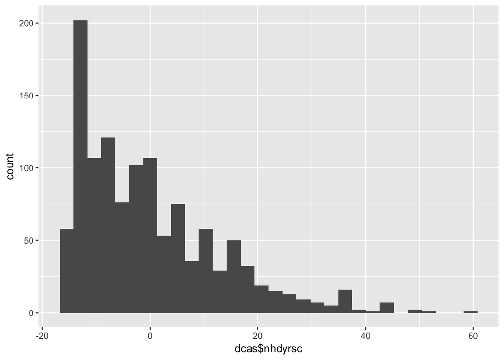

```r
dcas$nhdyrsc <- scale(dcas$nhdyrs, scale=FALSE)
qplot(dcas$nhdyrsc)
```

```r
dcas$nhdsize1 <- unclass(dcas$nhd.size)%in%c(1,2)
dcas$nhdsize2 <- unclass(dcas$nhd.size)%in%c(3,4)
dcas$nhdsize3 <- unclass(dcas$nhd.size)==5
for (i in 1:3) { ## Check recoding
    print(table(dcas[, c('nhd.size',paste0('nhdsize',i))]))
}
```

```
##                      nhdsize1
## nhd.size              FALSE TRUE
##   1 to 4 blocks           0  395
##   5 to 9 blocks           0  343
##   10 to 25 blocks       298    0
##   25 to 50 blocks       105    0
##   More than 50 blocks    58    0
##                      nhdsize2
## nhd.size              FALSE TRUE
##   1 to 4 blocks         395    0
##   5 to 9 blocks         343    0
##   10 to 25 blocks         0  298
##   25 to 50 blocks         0  105
##   More than 50 blocks    58    0
##                      nhdsize3
## nhd.size              FALSE TRUE
##   1 to 4 blocks         395    0
##   5 to 9 blocks         343    0
##   10 to 25 blocks       298    0
##   25 to 50 blocks       105    0
##   More than 50 blocks     0   58
```

```r
nhd_dummies <- paste0('nhdsize',1:3)
dcas[, paste0(nhd_dummies,'c')] <- scale(dcas[, nhd_dummies], scale=FALSE)

dcas$quad <- dcas$neighborhood=='Global Neighborhood'
table(dcas[,c('neighborhood','quad')])
```

```
##                      quad
## neighborhood          FALSE TRUE
##   Global Neighborhood     0  674
##   Latino Enclave        548    0
```

```r
dcas$quadc <- center('quad')

means <- c(means,
           apply(dcas[, c('nhdyrs', nhd_dummies, 'quadc')], 2, mean, na.rm=TRUE))
names <- c(names, '\\emph{Neighborhood Characteristics}\\\\Years in Neighborhood',
                  '1-9 blocks', '10-50 blocks', '>50 blocks',
                  'Quadrivial Neighborhood')
```

**Political Ideology**

- *Political ideology*, three categories based on Question 65: “In general, would you describe your political views as…”

```r
# dcas$pol1 <- unclass(dcas$dem.political)%in%c(1,2)
# dcas$pol2 <- unclass(dcas$dem.political)==3
# dcas$pol3 <- unclass(dcas$dem.political)%in%c(4,5)
# for(i in 1:3) { ## Check recoding
#     print(table(dcas[, c('dem.political', paste0('pol',i))]))
# }
# pol_dummies <- paste0('pol',1:3)
# dcas[, paste0(pol_dummies,'c')] <- scale(dcas[, pol_dummies], scale=FALSE)
#
# means <- c(means, apply(dcas[, pol_dummies], 2, mean, na.rm=TRUE))
# names <- c(names,
#            '\\emph{Political Ideology}\\\\Conservative', 'Moderate', 'Liberal')
```

## Descriptive Statistics

Descriptive statistics are calculated unweighted.

```r
varnames <- c('dem.race',names(means)[5:length(names(means))])
sigmas <- apply(dcas[, varnames[-1:-4]], 2, sd, na.rm=TRUE)
continuous_vars <- grep('age|nhdyrs',attr(sigmas, 'names'), perl=TRUE)
sigmas[-continuous_vars] <- NA
sigmas <- c(rep(NA,4), sigmas) # Add NAs for race variables

descriptives <- matrix(c(names, round(means, 2), round(sigmas, 2)), ncol=3)
descriptive_tbl <- as.table(descriptives)
colnames(descriptive_tbl) <- c('Variable', 'Mean', 'S.D.')
print.xtable(xtable(descriptive_tbl,
                    caption='Estimated means and standard deviations of independent and control variables',
                    align=c('l','l','p{.5in}','p{.5in}')),
                booktabs=TRUE,
                caption.placement='top',
                include.rownames=FALSE,
                file='analysis/tables/descriptives.tex',
                sanitize.text.function = identity)
```

## Analysis

### Multiple Imputation & Survey Weights

Several variables have a substantial amount of missing data. I used the Amelia package to create five imputation datasets that will be combined for the final results. I then set up the survey dseign using the list of imputed datasets to account for the complex survey design.

```r
vars <- c('satisfied', 'extremely_satisfied', 'better',  'much_better',
          'dem.race', 'agec', 'forbornc', 'manc', 'kidsc', 'marriedc',
          'educ1c', 'educ2c', 'educ3c', 'educ5c', 'inc1c',
          'inc3c', 'inc4c', 'nhdyrsc', 'nhdsize1c', 'nhdsize3c', 'quadc')
idvars <- c('studycase','weight', 'sample_strata')
dcassub <- dcas[, c(vars, idvars)]
nominals <- vars[!(vars %in% c('agec', 'nhdyrsc'))]
dcasmi <- amelia(dcassub, m=5, noms=nominals, emburn = c (500 , 500) , p2s = F, idvars=c('studycase','weight','sample_strata'))
dcassvy <- svydesign(id=~1,strata=~sample_strata,weights=~weight,data=imputationList(dcasmi$imputations))
```

### Satisfaction

#### Bivariate Relationship with Race

Plot the mean value of satisfaction by each racial group using survey weights.

```r
satisfied_means <- MIcombine(with(dcassvy,
                        svyby(~satisfied, ~dem.race, svymean)))
satisfied_means <- summary(satisfied_means)
```

```
## Multiple imputation results:
##       with(dcassvy, svyby(~satisfied, ~dem.race, svymean))
##       MIcombine.default(with(dcassvy, svyby(~satisfied, ~dem.race,
##     svymean)))
##                         results         se    (lower    upper) missInfo
## white:satisfiedFALSE  0.3207480 0.03460326 0.2528765 0.3886194      5 %
## api:satisfiedFALSE    0.3327334 0.04966214 0.2353304 0.4301365      5 %
## black:satisfiedFALSE  0.3248553 0.03889635 0.2483738 0.4013368     11 %
## latino:satisfiedFALSE 0.3115179 0.03850414 0.2359942 0.3870416      5 %
## white:satisfiedTRUE   0.6792520 0.03460326 0.6113806 0.7471235      5 %
## api:satisfiedTRUE     0.6672666 0.04966214 0.5698635 0.7646696      5 %
## black:satisfiedTRUE   0.6751447 0.03889635 0.5986632 0.7516262     11 %
## latino:satisfiedTRUE  0.6884821 0.03850414 0.6129584 0.7640058      5 %
```

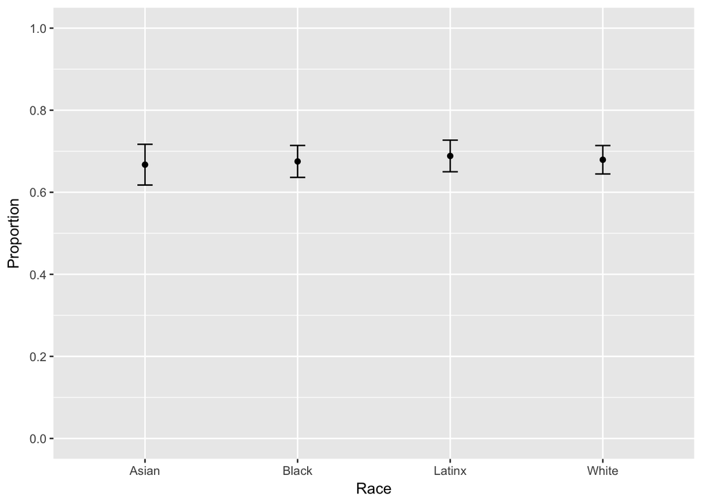

```r
satisfied_vals <- data.frame(dem.race=c('White','Asian','Black','Latinx'),
                             satisfied=satisfied_means[5:8,1],
                             ci=satisfied_means[5:8,2])
satisfied_plt <- ggplot(satisfied_vals, aes(x=dem.race, y=satisfied)) +
    geom_errorbar(aes(ymin=satisfied-ci, ymax=satisfied+ci), width=0.1) +
    geom_point() +
    scale_y_continuous(limits=c(0,1), breaks=seq(0,1,.20)) +
    labs(y='Proportion', x='Race')
satisfied_plt
```

```r
ggsave('analysis/images/satisfied_descriptive.png', plot=satisfied_plt,
            height=3, width=4, units='in')
```

**Extremely Satisfied.** Calculate the proportion of respondents who are *extremely* satisfied by each racial group.

```r
extreme_diffs <- MIcombine(with(dcassvy,
                    svyglm(extremely_satisfied ~ dem.race, family=quasibinomial)
                    ))
odds <- 1/exp(coef(extreme_diffs))
```

The odds of a white resident saying that they are extremely satisfied are 2 higher than Asians, 1.7 higher than blacks, and 1.54 than Latinx residents.

#### Multivariate Analysis

Runs three models. The first includes only race; the second adds demographic characteristics; and the third adds the resident’s experience with the neighborhood. Results are saved to LaTeX table saved at `analysis/tables/satisfaction.tex` (code suppressed).

```r
m1 <- MIcombine(with(dcassvy,
        svyglm(satisfied ~ dem.race, family=binomial)
))
m1 <- with(dcassvy,
           svyglm(satisfied ~ dem.race, family=quasibinomial))
summary(m1)
```

```
##      Length Class  Mode
## imp1 33     svyglm list
## imp2 33     svyglm list
## imp3 33     svyglm list
## imp4 33     svyglm list
## imp5 33     svyglm list
```

```r
m2 <- MIcombine(with(dcassvy,
        svyglm(satisfied ~ dem.race + agec + forbornc + manc + kidsc + marriedc +
               educ1c + educ2c + educ3c + educ5c + inc1c + inc3c + inc4c,
            family=quasibinomial)
))
summary(m2)
```

```
## Multiple imputation results:
##       with(dcassvy, svyglm(satisfied ~ dem.race + agec + forbornc +
##     manc + kidsc + marriedc + educ1c + educ2c + educ3c + educ5c +
##     inc1c + inc3c + inc4c, family = quasibinomial))
##       MIcombine.default(with(dcassvy, svyglm(satisfied ~ dem.race +
##     agec + forbornc + manc + kidsc + marriedc + educ1c + educ2c +
##     educ3c + educ5c + inc1c + inc3c + inc4c, family = quasibinomial)))
##                     results          se       (lower     upper) missInfo
## (Intercept)     0.807127420 0.170868716  0.472018356 1.14223648      5 %
## dem.raceapi    -0.089296027 0.324206747 -0.726185965 0.54759391      9 %
## dem.raceblack  -0.001349899 0.245277884 -0.482482042 0.47978224      5 %
## dem.racelatino  0.104222679 0.293749213 -0.473066018 0.68151138     10 %
## agec            0.004323917 0.005634809 -0.006722799 0.01537063      3 %
## forbornc        0.077458947 0.230499748 -0.374386569 0.52930446      2 %
## manc            0.164236268 0.184475867 -0.197334343 0.52580688      1 %
## kidsc          -0.340744747 0.203825699 -0.740270350 0.05878086      2 %
## marriedc        0.141614025 0.204634061 -0.259465146 0.54269320      1 %
## educ1c         -0.281329713 0.374182696 -1.015276991 0.45261756      5 %
## educ2c          0.528376002 0.334443264 -0.128423664 1.18517567      8 %
## educ3c         -0.033495059 0.257448444 -0.538416710 0.47142659      5 %
## educ5c         -0.122212171 0.244477189 -0.601738998 0.35731466      5 %
## inc1c          -0.200417019 0.273351188 -0.737705572 0.33687154     10 %
## inc3c          -0.029951673 0.247296164 -0.516665255 0.45676191     12 %
## inc4c          -0.053641521 0.308429432 -0.659576319 0.55229328      9 %
```

```r
m3 <- MIcombine(with(dcassvy,
        svyglm(satisfied ~ dem.race + agec + forbornc + manc + kidsc + marriedc +
                 educ1c + educ2c + educ3c + educ5c + inc1c + inc3c + inc4c +
                 nhdyrsc + nhdsize1c + nhdsize3c + quadc,
            family=quasibinomial)
))
summary(m3)
```

```
## Multiple imputation results:
##       with(dcassvy, svyglm(satisfied ~ dem.race + agec + forbornc +
##     manc + kidsc + marriedc + educ1c + educ2c + educ3c + educ5c +
##     inc1c + inc3c + inc4c + nhdyrsc + nhdsize1c + nhdsize3c +
##     quadc, family = quasibinomial))
##       MIcombine.default(with(dcassvy, svyglm(satisfied ~ dem.race +
##     agec + forbornc + manc + kidsc + marriedc + educ1c + educ2c +
##     educ3c + educ5c + inc1c + inc3c + inc4c + nhdyrsc + nhdsize1c +
##     nhdsize3c + quadc, family = quasibinomial)))
##                     results          se      (lower      upper) missInfo
## (Intercept)     0.804835932 0.171519583  0.46850395  1.14116791      4 %
## dem.raceapi    -0.044798695 0.331080473 -0.69504174  0.60544435      9 %
## dem.raceblack   0.004084254 0.251121116 -0.48877798  0.49694648      7 %
## dem.racelatino  0.199758993 0.295687182 -0.38104902  0.78056701      9 %
## agec            0.005939444 0.006527970 -0.00685880  0.01873769      3 %
## forbornc        0.012922402 0.232663211 -0.44319195  0.46903675      3 %
## manc            0.215485784 0.185268327 -0.14763853  0.57861010      1 %
## kidsc          -0.354792404 0.203979657 -0.75460588  0.04502107      1 %
## marriedc        0.151099645 0.201833224 -0.24448979  0.54668908      1 %
## educ1c         -0.261826366 0.378525557 -1.00478185  0.48112911      7 %
## educ2c          0.631147738 0.348221209 -0.05337363  1.31566910     10 %
## educ3c         -0.055937309 0.258533882 -0.56324531  0.45137069      6 %
## educ5c         -0.157713255 0.243817158 -0.63610224  0.32067573      6 %
## inc1c          -0.141932837 0.272615388 -0.67890331  0.39503764     13 %
## inc3c          -0.036650232 0.251137089 -0.53301909  0.45971863     18 %
## inc4c          -0.071473705 0.324337359 -0.71061870  0.56767129     14 %
## nhdyrsc        -0.005186107 0.008838628 -0.02251036  0.01213814      1 %
## nhdsize1c      -0.702027259 0.196486211 -1.08713321 -0.31692131      0 %
## nhdsize3c      -0.467623912 0.416211435 -1.28339846  0.34815063      1 %
## quadc           0.232179756 0.192359945 -0.14484564  0.60920515      1 %
```

### Neighborhood Improvement

Calculate the proportion of respondents who indicated that they think that the neighborhood has gotten better in the past five years.

```r
better_means <- MIcombine(with(dcassvy,
                        svyby(~better, ~dem.race, svymean)))
better_means <- summary(better_means)
```

```
## Multiple imputation results:
##       with(dcassvy, svyby(~better, ~dem.race, svymean))
##       MIcombine.default(with(dcassvy, svyby(~better, ~dem.race, svymean)))
##                      results         se    (lower    upper) missInfo
## white:betterFALSE  0.6436265 0.03594539 0.5731449 0.7141081      4 %
## api:betterFALSE    0.5747938 0.05237951 0.4719837 0.6776040      7 %
## black:betterFALSE  0.6251443 0.04118850 0.5441553 0.7061334     11 %
## latino:betterFALSE 0.5638610 0.04032772 0.4848163 0.6429057      1 %
## white:betterTRUE   0.3563735 0.03594539 0.2858919 0.4268551      4 %
## api:betterTRUE     0.4252062 0.05237951 0.3223960 0.5280163      7 %
## black:betterTRUE   0.3748557 0.04118850 0.2938666 0.4558447     11 %
## latino:betterTRUE  0.4361390 0.04032772 0.3570943 0.5151837      1 %
```

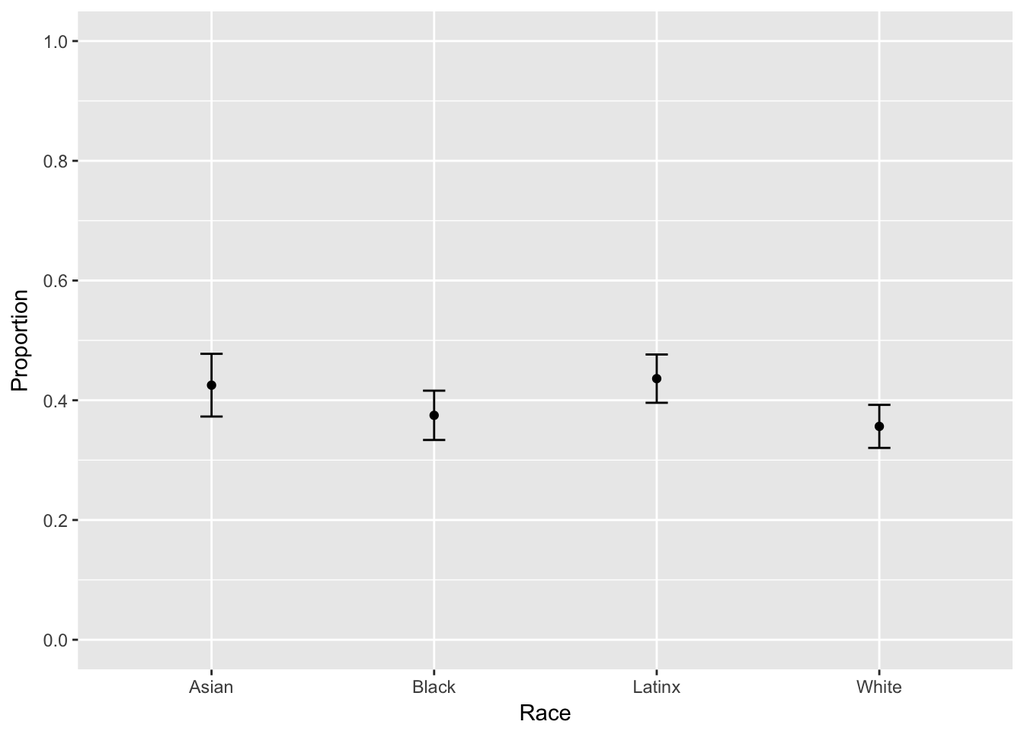

```r
better_vals <- data.frame(dem.race=c('White','Asian','Black','Latinx'),
                          better=better_means[5:8,1],
                          ci=better_means[5:8,2])
better_plt <- ggplot(better_vals, aes(x=dem.race, y=better)) +
    geom_errorbar(aes(ymin=better-ci, ymax=better+ci), width=0.1) +
    geom_point() +
    scale_y_continuous(limits=c(0,1), breaks=seq(0,1,.20)) +
    labs(y='Proportion', x='Race')
better_plt
```

```r
ggsave('analysis/images/better_descriptive.png', plot=satisfied_plt,
            height=3, width=4, units='in')
better_model <- MIcombine(with(dcassvy,
                    svyglm(better ~ dem.race, family=quasibinomial)))
```

The graph above shows that Latinos and Asians were more likely to say that the neighborhood has improved while blacks and whites are less likely to say that their neighborhoods have improved. The differences, however, are not statistically distinguishable.

But, there is a difference for those who say that the neighborhood has gotten “much better” over the past five years. Whites, on this measure, were much less likely to indicate that their neighborhoods have gotten much better. I examine whether that might be due to the fact that whites are more likely to say that they are “extremely satisfied” in their neighborhoods relative to other racial groups.

```r
much_better_means <- MIcombine(with(dcassvy,
                        svyby(~much_better, ~dem.race, svymean)))
much_better_means <- summary(much_better_means)
```

```
## Multiple imputation results:
##       with(dcassvy, svyby(~much_better, ~dem.race, svymean))
##       MIcombine.default(with(dcassvy, svyby(~much_better, ~dem.race,
##     svymean)))
##                            results         se     (lower    upper)
## white:much_betterFALSE  0.91722296 0.02167231 0.87443616 0.9600097
## api:much_betterFALSE    0.83178972 0.04030214 0.75278946 0.9107900
## black:much_betterFALSE  0.83534190 0.03290720 0.77084137 0.8998424
## latino:much_betterFALSE 0.80558320 0.03389006 0.73915246 0.8720139
## white:much_betterTRUE   0.08277704 0.02167231 0.03999025 0.1255638
## api:much_betterTRUE     0.16821028 0.04030214 0.08921003 0.2472105
## black:much_betterTRUE   0.16465810 0.03290720 0.10015758 0.2291586
## latino:much_betterTRUE  0.19441680 0.03389006 0.12798605 0.2608475
##                         missInfo
## white:much_betterFALSE      16 %
## api:much_betterFALSE         2 %
## black:much_betterFALSE       1 %
## latino:much_betterFALSE      2 %
## white:much_betterTRUE       16 %
## api:much_betterTRUE          2 %
## black:much_betterTRUE        1 %
## latino:much_betterTRUE       2 %
```

```r
much_better_vals <- data.frame(dem.race=c('White','Asian','Black','Latinx'),
                               much_better=much_better_means[5:8,1],
                               ci=much_better_means[5:8,2])
much_better_plt <- ggplot(much_better_vals, aes(x=dem.race, y=much_better)) +
    geom_errorbar(aes(ymin=much_better-ci, ymax=much_better+ci), width=0.1) +
    geom_point() +
    scale_y_continuous(limits=c(0,1), breaks=seq(0,1,.20)) +
    labs(y='Proportion', x='Race')

much_better_model <- MIcombine(with(dcassvy,
                        svyglm(much_better ~ dem.race, family=quasibinomial)))
much_better_satis_model <- MIcombine(with(dcassvy,
                        svyglm(much_better ~ dem.race + extremely_satisfied,
                               family=quasibinomial)))
betas <- much_better_satis_model$coefficients
odds <- exp(betas)
odds
```

```
##         (Intercept)         dem.raceapi       dem.raceblack
##          0.03979128          3.25109683          2.97372179
##      dem.racelatino extremely_satisfied
##          3.59377887          6.09347473
```

```r
list(coef(much_better_model), coef(much_better_satis_model))
```

```
## [[1]]
##    (Intercept)    dem.raceapi  dem.raceblack dem.racelatino
##     -2.4089508      0.8102133      0.7848064      0.9872043
##
## [[2]]
##         (Intercept)         dem.raceapi       dem.raceblack
##           -3.224107            1.178992            1.089814
##      dem.racelatino extremely_satisfied
##            1.279204            1.807218
```

## Notes

Consider only using educational attainment rather than both education and income. The two are highly correlated and would avoid having to impute.

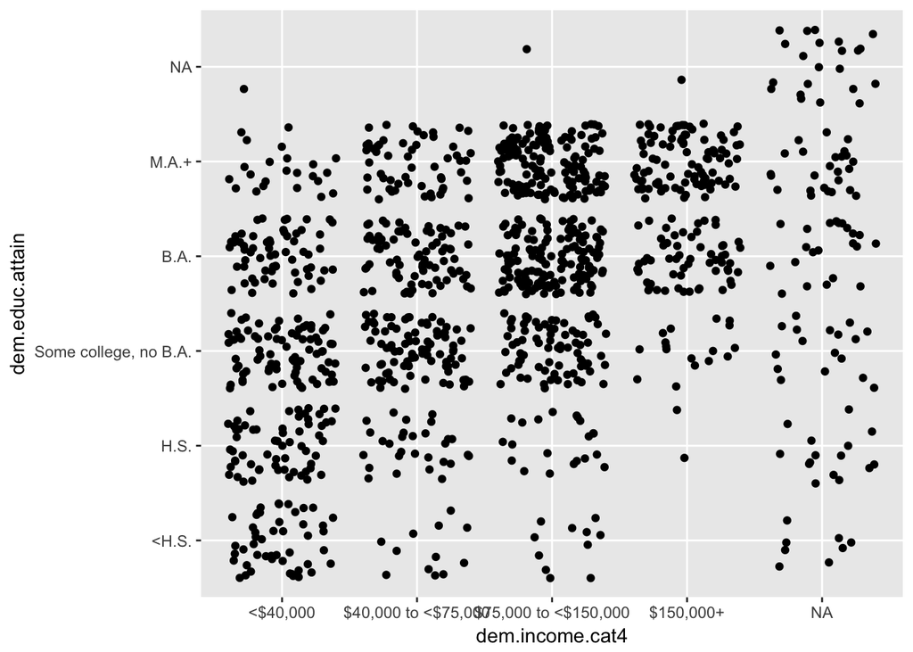

```r
ggplot(dcas, aes(x=dem.income.cat4,y=dem.educ.attain)) + geom_jitter()
```